# Free Software Melbourne

## Free Software

## Show & Tell

#### with Bits and Bytes of all the best Gnews

###### 17th November 2016

###### Hosting (of various kinds) provided by:

System Saviour Ben Sturmfels Electron Workshop

# Gnews :: Things to do

## Pardon Julian Assange

- We believe Mr. Assange must be granted a presidential pardon absolving him of any crimes alleged against him
- [Petition](https://www.change.org/p/donald-trump-pardon-julian-assange)

[figure not shown]

## Tim Berners-Lee just gave us an opening to stop DRM in Web standards

- delegated the decision to the W3C's general decision-making body,, it's entirely possible that the Advisory Committee will reject the time extension and terminate EME development
- Concerned individuals can take action by signing Defective by Design's petition or adding a protest selfie to the growing gallery
- [Article](https://defectivebydesign.org/blog/tim_bernerslee_just_gave_us_opening_stop_drm_web_standards)
- [Petition](https://my.fsf.org/civicrm/profile/create%3Fgid%3D183%26reset%3D1)
- [Gallery](https://www.defectivebydesign.org/selfie-against-drm-in-web-standards)
- [Twitter](https://mobile.twitter.com/endDRM/status/796475563204550656)

## EFF: Copyright Law Shouldn't Punish Research and Repair

- As locked-down copyrighted software shows up in more and more devices, from phones to refrigerators to tractors, more and more people are realizing how important it is to be able to break those locks
- As part of an ongoing study, it’s asking for comments (PDF) on whether it should recommend that Congress enact a series of permanent exemptions
- Zoe Lofgren’s Unlocking Technology Act, which would protect those who want to break digital locks for noninfringing reasons
- Making a few of those exemptions permanent would let us all focus our energies on expanding the reach of the temporary ones, and working to streamline the process so it is less burdensome for both users and the government.
- [Petition](https://act.eff.org/action/copyright-law-shouldn-t-punish-research-and-repair)
- [Article](https://www.eff.org/deeplinks/2016/10/tell-copyright-office-copyright-law-shouldnt-punish-research-and-repair)

# Gnews :: Free Culture

## Operation upgrade: A failed Windows laptop program was turned into a Linux success.

- by the school computing club (Asian Penguins)
- they launched an Indiegogo campaign. they raised more money than they needed, and they also received a donation of laptops
- [Article](https://opensource.com/education/16/9/asian-penguins-convert-minnesota-school-linux)
- [Indiegogo](https://www.indiegogo.com/projects/cse-asian-penguins-seek-to-replace-laptops#/)

[figure not shown]

## Internet Archive turns 20

- repository of modern culture
- more than 370 million websites and 273 billion pages, many captured before they disappeared forever
- a virtual storehouse ranging from digitally converted books and historic film to funny memes and audio recordings of Grateful Dead concerts
- who thought the Web was anything that needed to be saved back in 1996
- The Internet Archive has survived through community donations and by working with about 1,000 libraries
- The site’s 3 million to 4 million visitors a day show that “people want old stuff, they want to remember,”
- [Wayback Machine](https://archive.org/web/)
- [Article](http://www.sfchronicle.com/business/article/Internet-Archive-repository-of-modern-culture-10421008.php)

## Wikipedia community and Internet Archive partner to fix one million broken links

- on Wikipedia... updated to archived versions from the Wayback Machine
- testament to the sharing, cooperative nature and resulting benefits of the open world
- provide persistent availability to reference information
- [Article](https://blog.wikimedia.org/2016/10/26/internet-archive-broken-links/)

## Eben Moglen, Software Freedom Through Diplomacy

- [Video](https://www.youtube.com/watch?v=okEQt-Rla7o)

## All things open isn't just about technology

- Jim Whitehurst interview
- They recognize the company that builds the community around that piece of technology, that technology is going to win
- [Article](http://www.bizjournals.com/triangle/news/2016/10/26/red-hat-ceo-all-things-open-isnt-just-about.html)

## Linux marketshare had passed 2% for the first time

- September 2016 was almost as good at 2.23%.
- Tracking data from Wikimedia, shows a more familiar figure of ~1.2% for Linux based on data over the same three months
- [Article](http://www.omgubuntu.co.uk/2016/10/linux-marketshare-2-percent-3rd-month-row)

## U.S. government launches Code.gov to showcase its open-source software

- the White House is hoping to improve public access to the government’s software and encourage the reuse of software across government agencies
- months after the White House introduced the Federal Source Code policy, which specifically mandates that government agencies “make custom-developed code available for Government-wide reuse and make their code inventories discoverable”
- [Article](http://venturebeat.com/2016/11/03/u-s-government-launches-code-gov-to-showcase-its-open-source-software/)

## open source Java is still controversial

- Sun chose to shift Java to the GNU General Public License, which then-Sun CEO Jonathan Schwartz called a “momentous” change
- In particular, the Java SE and Java EE TCKs [Technology Compatibility Kits] remain closed source
- Sun and Oracle fully control Java-related intellectual property and copyrights through the JCP
- [Article](http://www.infoworld.com/article/3138505/java/open-source-java-at-10-big-benefits-but-detractors-remain.html)

# ‘Why Use Linux?’

[figure not shown]

## ‘Why Use Linux?’ Answered In 3 Short Words

- TLDR: `cause
- [Article](http://www.omgubuntu.co.uk/2016/10/why-use-linux-answer-three-short-words)

# Gnews :: Open Hardware / Firmware

## first open source hack-proof Wi-Fi

- NIC.cz has come up with Turris Omnia WiFi Router
- NIC.cz has open-sourced the Turris Omnia firmware making it easy for automatic updates and patching vulnerabilities
- the ability of Turris Omnia to self-update and also communicate with other routers and share information about possible security threats makes it unique
- both the hardware and software are open source so people with the necessary knowledge can further tinker
- [Article](http://www.techworm.net/2016/10/worlds-first-hack-proof-wi-fi-router-open-source-firmware.html)

## $4, coin-sized, open-source Linux computer

- VoCore2 is an open source Linux computer and a fully-functional wireless router that is smaller than a coin
- 580MHz MT7688AN MediaTek system on chip (SoC), 64MB of DDR2 RAM, 8MB of NOR storage, and a single antenna slot for Wi-Fi that supports 150Mbps
- Spend $12 and go for the full VoCore2 option and you get the same SoC, but you get 128MB of DDR2 RAM, 16MB of NOR storage, two antenna slots supporting 300Mbps, an on-board antenna, and PCIe 1.1 support
- [Article](http://www.zdnet.com/article/move-over-raspberry-pi-here-is-a-4-coin-sized-open-source-linux-computer/)
- [IndieGogo](https://www.indiegogo.com/projects/vocore2-4-coin-sized-linux-computer-with-wifi#/)

## Freeing my tablet

- Getting root access to a tablet
- [Article](https://www.thanassis.space/android.html)

## Lenovo releases BIOS for loading Linux on Yoga 900

- Lenovo’s new BIOS has an AHCI option that lets you install Linux… but if you’re using the new BIOS, then Windows is not officially supported. In fact, Lenovo says it’s not officially supporting the new BIOS either… if you want to install it, you’re pretty much on your own
- [Article](https://liliputing.com/2016/11/lenovo-releases-bios-loading-linux-yoga-900-ideapad-710s-bios.html)

## Android Auto: now available in every car

- (on your own phone)
- automatically start the app when the phone is paired with your car’s Bluetooth network
- [Article](https://blog.google/products/android/android-auto-available-in-every-car/)
- [another Article](https://techcrunch.com/2016/11/07/google-brings-android-auto-to-the-phone/)

## MP3 in Fedora and Gnome

- Mp3 support now coming to Fedora Workstation
- our initial enablement is through the mpeg123 library and corresponding GStreamer plugin
- using the same license as GStreamer (lgpl v2) and being a well established library
- [Article](https://blogs.gnome.org/uraeus/2016/11/10/mp3-support-now-coming-to-fedora-workstation-25/)

## broadband start-up arrives in Australia with 100 mbps 'true NBN' offering

- nothing but top speed
- [Article](http://www.smh.com.au/business/consumer-affairs/myrepublic-broadband-startup-arrives-in-australia-with-100-mbps-true-nbn-offering-20161103-gshbip.html)

[figure not shown]

## NES Classic Is a Quad-Core Linux Computer

- System on a Chip: Allwinner R16 (4x Cortex A7, Mali400MP2 GPU)
- RAM: SKHynix (256MB DDR3)
- Flash: Spansion 512MB SLC NAND flash, TSOP48
- If you consider the original NES used a processor running at just 1.79MHz
- [Article](http://www.pcmag.com/news/349355/nes-classic-is-a-quad-core-linux-computer)

# Gnews :: Releases

## Microsoft Is Getting Busy on GitHub

- The next wave of open technologies may very well be powered by some closed-source giants. This is kind of like a renaissance
- Open Lock-In Is Still Real
- If you run an application using an open source technology, regardless of what it is, you are most likely a little locked in
- [Article](https://dzone.com/articles/microsoft-is-getting-busy-on-github)

## MS releases Azure Container Service engine

- allows developers to orchestrate applications using Apache Mesos or Docker Swarm. ACS also enables users to migrate container workloads to and from Azure without code changes
- the preview of Kubernetes running natively on ACS is now available
- allow developers to set up integration and deployment of multi-container Linux apps using Visual Studio, Visual Studio Team Services, and Visual Studio Code
- [Code](https://github.com/Azure/acs-engine)
- [Article](http://www.zdnet.com/article/microsoft-open-sources-its-azure-container-service-engine/)

## Rust Language Server

- self-contained, full-featured application for IDE support.
- being self-contained, and following a simple protocol, all the core IDE functionality will be available to any editor
- We still have a lot of work to get there
- Currently, Eclipse and Visual Studio Code support this protocol
- [Article](http://www.infoworld.com/article/3132449/application-development/mozillas-rust-goes-real-time-with-code-feedback.html%5D)
- [Video](https://www.youtube.com/watch?time_continue=2405&v=pTQxHIzGqFI%5D)
- [Source](https://github.com/jonathandturner/rustls)

[figure not shown]

## Mozilla Announces Quantum, a New Browser Engine for Firefox

- take parts of the Servo project and create a new core for the Firefox browser, toreplace the aging Gecko
- rely on components from Servo, a browser engine that Mozilla has been sponsoring (Rust)
- simpler, faster, newer, stronger
- [Article](http://news.softpedia.com/news/mozilla-announces-quantum-a-new-browser-engine-for-firefox-509767.shtml)
- [Mozilla](https://wiki.mozilla.org/Quantum)

## Amazon Linux container image for use in on-premises data centers

- released a container image of its Amazon Linux operating system — which has, until now, only been accessible on AWS virtual machine instances — that customers can now deploy on their own servers
- Amazon Linux is not currently available for instant deployment on other public clouds
- [Docs](http://docs.aws.amazon.com/AmazonECR/latest/userguide/amazon_linux_container_image.html)
- [Article](http://venturebeat.com/2016/11/15/aws-launches-quicksight-business-intelligence-tool-out-of-preview/)

## Corda platform to be open-source

- Blockchain platform developed by a group that includes more than 70 of the world's biggest financial institutions is making its code publicly available, in what could become the industry standard for the nascent technology
- R3 says it hopes its platform will become the industry standard, although its intention is indeed for firms to build products on top of it
- [Article](http://www.reuters.com/article/us-banks-blockchain-r3-exclusive-idUSKCN12K17E)

# Unreleases

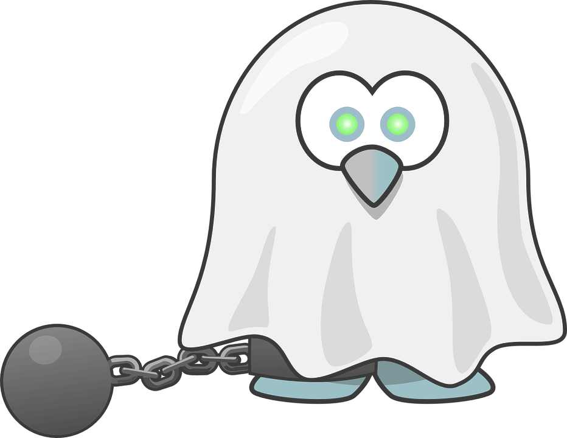

## Linux 4.7 kernel branch officially reached end of life

- kernel 4.7.10 maintenance update is the last one that will be released
- [Article](http://news.softpedia.com/news/linux-kernel-4-7-10-is-the-last-in-the-series-users-need-to-move-to-linux-4-8-509555.shtml)

# Gnews :: Security & Privacy & DRM

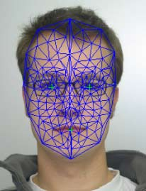

## Halloween Christmas? costumes for Digital Rights Activists

- Honorable mention goes to "Certbot"
- [Article](https://www.eff.org/deeplinks/2016/10/five-halloween-costumes-digital-rights-activists)

## EFF: Facial Recognition’s Threat to Privacy is Worse Than Anyone Thought

- A brand new report from the Georgetown Law Center for Privacy and Technology indicates the problem is far worse than we could’ve imagined
- One in two American adults has their image in a facial recognition network, more than 117 million people
- almost completely unregulated
- recognition systems have a disproportionate impact on Communities of Color
- [Report](https://www.perpetuallineup.org/)
- [EFF Letter](https://www.aclu.org/letter/coalition-letter-department-justice-civil-rights-division-calling-investigation-disparate)
- [Article](https://www.eff.org/deeplinks/2016/10/memo-doj-facial-recognitions-threat-privacy-worse-anyone-thought)

## Majority of Activity on the Dark Web is Totally Legal and Mundane

- Terbium Labs has conducted the industry's first data-driven, fact-based research report that looked to identify what's really taking place
- All quantitative findings in The Truth About the Dark Web: Separating Fact from Fiction are reported along with a measure of confidence, a margin of error, as well as a consideration of potential sources of error
- Legal content comprised 54.5% of the dark web content observed
- [Article](http://www.digitaljournal.com/pr/3126193)

## FSF urging the U.S. Government to drop the DMCA's anti-circumvention provisions

- play no legitimate role in protecting copyrighted works. Instead, they are a means of controlling users and creating ‘lock in’
- should at minimum broaden the existing permanent exemptions to more uses
- [Article](https://torrentfreak.com/drm-is-used-to-lock-in-control-and-spy-on-users-161108/)

## EA seems to be comming to the party

- Three More EA Games Drop DRM on PC for GOG Release
- Crysis, Crysis Warhead, and Medal of Honor: Pacific Assault are each now available on GOG
- first time they've been offered without DRM
- [Article](http://www.gamespot.com/articles/three-more-ea-games-drop-drm-on-pc-for-gog-release/1100-6444873/)

## ‘Dirty Cow’ can Root every version of Android

- cataloged in the Linux kernel’s bug tracker system as CVE-2016-5195
- flaw is located in a section of the Linux kernel that's a part of virtually every distribution
- The security vulnerability is said to be rather trivial to exploit
- any web server/application vulnerability which allows the attacker to upload a file to the impacted system and execute it also works
- For the past few years, I have been capturing all inbound traffic to my webservers for forensic analysis. This practice has proved invaluable on numerous occasions, and I would recommend it to all admins. In this case, I was able to extract the uploaded binary from those captures to analyze its behavior, and escalate to the appropriate Linux kernel maintainers
- race condition, was found in the way Linux memory handles a duplication technique called copy on write
- [Article](http://arstechnica.com/security/2016/10/most-serious-linux-privilege-escalation-bug-ever-is-under-active-exploit/)
- [Article](http://www.xda-developers.com/9-year-old-linux-kernel-bug-dubbed-dirty-cow-can-root-every-version-of-android/)

## Android Patch For High-Severity 'Dirty COW' Linux Kernel Flaw Delayed

- Dirty COW patch couldn’t land in the November security update
- coordinated release also ensures that at least some devices get fixed for the vulnerabilities
- Other Serious Flaws Fixed In The November Update
- [Article](http://www.tomshardware.com/news/android-dirty-cow-delayed-patch,32994.html)

## Two Critical MySQL Bugs Discovered

- and MariaDB, and PerconaDB
- [Slashdot](https://developers.slashdot.org/story/16/11/05/056227/two-critical-mysql-bugs-discovered)

## Snowden corrects the record

- Hey @Snowden, for context, how long would it take the NSA to dedupe 650k emails?
- @jeffjarvis Drop non-responsive To:/CC:/BCC:, hash both sets, then subtract those that match. Old laptops could do it in minutes-to-hours.
- [Article](https://www.yahoo.com/news/edward-snowden-crushes-conspiracy-theory-053349259.html)
- [other Article](http://www.geekwire.com/2016/fbi-650000-emails-edward-snowden/)

## FileZilla Fork?

- A big part of security in passwords is protecting users from themselves
- [Homepage](http://www.filezillasecure.com/)
- [Article](https://www.reddit.com/r/software/comments/5b7gnd/introducing_filezilla_secure_a_modified_version/)

## Web of Trust is caught selling users' browsing histories

- Web of Trust Services (WoT) had been harvesting netizens' web browsing histories through its browser add-on and then selling them
- WoT claimed it anonymised the data
- we now believe that our data cleaning techniques may not have been sufficient to fully anonymize the browsing data
- [Article](http://www.theregister.co.uk/2016/11/07/browsers_ban_web_of_trust_addon_after_biz_is_caught_selling_its_users_browsing_histories/)

## CBC threatens podcast app makers, argues that RSS readers violate copyright

- CBC has begun to send legal threats to podcast app-makers, arguing that making an app that pulls down public RSS feeds is a "commercial use" and a violation of the public broadcaster's copyrights
- There is an implied license when you put something on the web that it is there to link to
- [Article](https://boingboing.net/2016/11/08/cbc-threatens-podcast-app-make.html)

# Gnews :: Distro News

## NetBSD 7.0.2 release

- OpenSSL 1.0.1u, NTP 4.2.8p8, BIND 9.10.4-P3, and root.cache 20160825 updated components
- [Release](http://linux.softpedia.com/blog/netbsd-7-0-2-operating-system-officially-released-available-for-download-now-509739.shtml)

## Fedora 25 Beta Linux distro available for Raspberry Pi

- a proper Fedora supported upstream userspace and kernel, with all the standard Fedora features like SELinux support
- [Announce](http://betanews.com/2016/10/19/fedora-25-beta-linux-raspberry-pi/)

## Debian alpha 8

- why the "split" between / and /usr doesn't really work out for Debian these days and that trying to maintain it for some configurations (which are not documented) is mostly busy-work
- [Comments](https://lists.debian.org/debian-devel/2016/09/msg00269.html)
- [Announce](https://lists.debian.org/debian-devel-announce/2016/11/msg00006.html)

## enable 'Canonical Livepatch Service' for Linux kernel live-patching

- Ubuntu 16.04 LTS (with generic Linux kernel 4.4)
- does have a catch -- it is limited to three machines per user. Of course, home users can register as many email addresses as they want, so it is easy to get more if needed
- [Article](http://betanews.com/2016/10/20/how-to-enable-free-canonical-livepatch-service-linux-kernel-live-patch-ubuntu/)

## Ubuntu Budgie Is Now an Official Ubuntu

- Budgie desktop makes use of modern GNOME technologies but is not a GNOME fork
- [Article](http://www.omgubuntu.co.uk/2016/11/ubuntu-budgie-now-official-ubuntu-flavor)

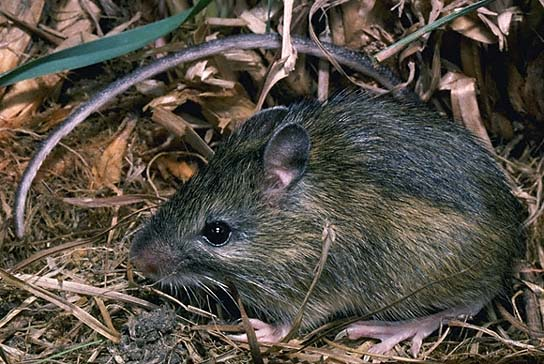

## Canonical has chosen "Zesty Zapus" (jumping mice)

- That is all
- [Article](http://betanews.com/2016/10/17/canonical-ubuntu-linux-17-04-zesty-zapus/)

# Gnews :: Unfortunate Gnews

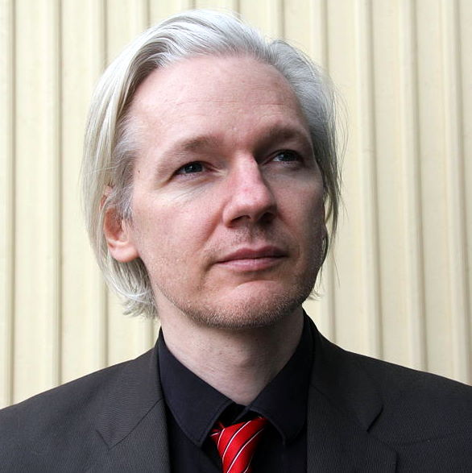

## Ecuador limiting Julian Assange's web access

- activated "contingency plans" after Assange's cut-off, and Ecuador said that its action did not stop the group continuing "journalistic activities."
- [Article](http://www.reuters.com/article/us-usa-cyber-wikileaks-ecuador-idUSKCN12I2V7)

## It's complicated but... Munich may abandon Linux

- In a while... Windows trial about to begin
- [Article](http://www.techrepublic.com/article/open-source-pioneer-munich-debates-report-that-suggests-abandoning-linux-for-windows-10/)

# Gnews :: The Good, The Bad and The Ugly

## The Good

### Assange on the election

- the real victor is the US public which is better informed as a result of our work
- [Article](https://wikileaks.org/Assange-Statement-on-the-US-Election.html)

### Congress will abandon Trans-Pacific Partnership deal, White House concedes

- congressional leaders from both parties say they will not bring trade deal forward
- [Article](https://www.theguardian.com/business/2016/nov/12/tpp-trade-deal-congress-obama)

## the Bad

### How President Trump Could Destroy Net Neutrality

- [Slashdot](https://politics.slashdot.org/story/16/11/10/2118208/how-president-trump-could-destroy-net-neutrality)

## the Ugly

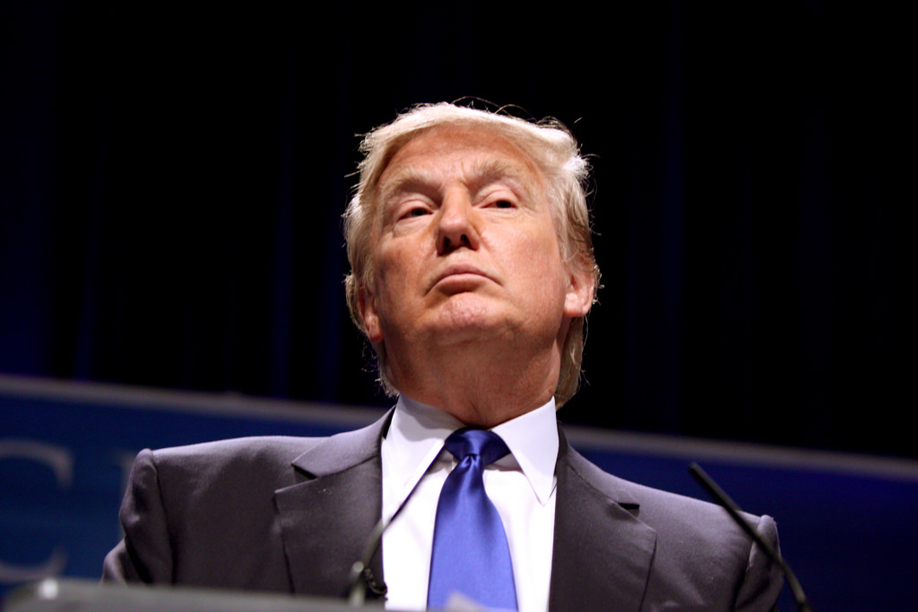